[Статьи]

# Методика расчёта электрической мощности турбодетандера

Давление в магистральных газопроводах превышает 10 МПа(и), давление в газопроводах в пределах населённых пунктов - менее 0,6 МПа(и). Частичное снижение давления газа происходит из-за преодоления сопротивления его движению по трубам, но значительную часть перепада давления приходится уменьшать специально - дросселированием либо "заставляя" газ совершать полезную работу.

Для полезного использования перепада давления газа применяют турбодетандер, представляющий собой центробежную или осевую турбину, в которой за счёт расширения газа совершается работа, используемая для привода генератора (выработки электроэнергии).

Для идеального газа техническая (полезная) работа, совершаемая потоком газа при прохождении через турбодетандер 1 кг газа (удельная работа), находится по формуле:

$$l_{техн} = \frac{kp_1v_1}{k-1}\left(1 - (p_2/p_1)^{\frac{k-1}{k}}\right)\eta = \frac{kRT_1}{k-1}\left(1 - (p_1/p_2)^{\frac{1-k}{k}}\right)\eta$$

где $p_1$ - абсолютное давление газа перед турбодетандером, Па; $p_2$ - абсолютное давление газа за турбодетандером, Па; $v_1$ - удельный объём газа перед турбодетандером, $м^3/кг$; $T_1$ - температура газа перед турбодетандером, К; $k$ - показатель адиабаты; $R$ - газовая постоянная, Дж/кг/К; $\eta$ - коэффициент полезного действия турбодетандера.

Из приведённой формулы видно, что увеличение температуры газа (в градусах Кельвина) на X % даст прирост удельной работы на те же X %. Предельная температура нагрева газа - температура самовозгорания.

При совершении газом полезной работы $l_{техн}$ его температура снижается на величину $dt$

$$dt = l_{техн} \frac{k-1}{kR}$$

Необходимо помнить, что температура газа на выходе из турбодетандера должна быть выше температуры точки росы.

Построим зависимость удельной полезной работы метана от величины $p_1/p_2$ и температуры метана перед турбодетандером $t_1$.

```python
R_mu = 8.31  # универсальная газовая постоянная, Дж/моль/К
mu = 12 + 4  # молярная масса метана, г/моль
k = 4 / 3  # показатель адиабаты трёх и более атомного газа
R = R_mu / mu * 1e3  # газовая постоянная метана, Дж/кг/К
КПД = 0.85  # КПД турбодетандера
R
```

```
519.375
```

```python
def fl(eps, t1):
    # Расчёт удельной технической работы
    # eps = p1/p2
    # t1 - температура газа, С
    # return - удельная работа, Дж/кг
    return k * R * (t1 + 273.15) / (k - 1) * (1 - eps ** ((1 - k) / k)) * КПД
```

```python
import numpy as np
t1s = np.array([15, 50, 100, 150, 200])  # значения температуры t1
```

```python
epss = np.linspace(1, 10, 100)  # p1/p2
```

```python
ls = np.array([[fl(eps, t) for t in t1s] for eps in epss])  # расчёт удельной работы
```

```python
import matplotlib.pyplot as plt  # библиотека для построения графиков
plt.rcParams['font.size'] = 12.0
```

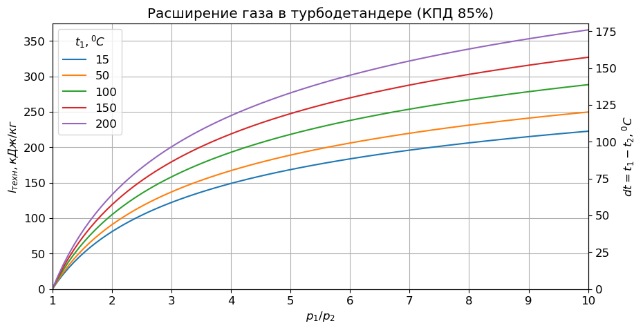

```python
fig, ax = plt.subplots(figsize = (10,5))
ax.set_title("Расширение газа в турбодетандере (КПД 85%)");
ax.set_xlabel('$p_1/p_2$'); ax.set_ylabel('$l_{техн}, кДж/кг$')
l_max = 375e3  # верхнее значение оси y
ax.grid(); ax.set_xlim(1, epss[-1]); ax.set_ylim(0,l_max / 1000);
ax2 = ax.twinx(); ax2.set_ylabel('$dt=t_1-t_2, ^0C$')
ax2.set_ylim(0, l_max * (k - 1) / k / R);
ax.plot(epss, ls / 1000);
ax.legend(t1s, title = '$t_1, ^0C$');
```

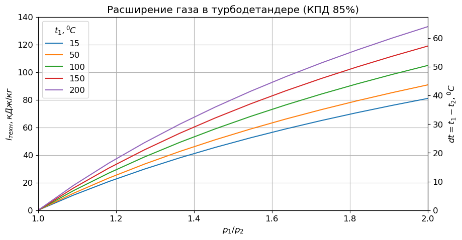

```python
fig, ax = plt.subplots(figsize = (10,5))
ax.set_title("Расширение газа в турбодетандере (КПД 85%)");
ax.set_xlabel('$p_1/p_2$'); ax.set_ylabel('$l_{техн}, кДж/кг$')
l_max = 140e3  # верхнее значение оси y
ax.grid(); ax.set_xlim(1, 2); ax.set_ylim(0,l_max / 1000);
ax2 = ax.twinx(); ax2.set_ylabel('$dt=t_1-t_2, ^0C$')
ax2.set_ylim(0, l_max * (k - 1) / k / R);
ax.plot(epss, ls / 1000);
ax.legend(t1s, title = '$t_1, ^0C$');
```

Рассмотрим электростанцию с блоком ПГУ на базе ГТУ мощностью 160 МВт (тогда мощность блока ПГУ составит порядка 160+160/2=240 МВт). В качестве топлива ГТУ к электростанции подводится газ давлением 5 МПа(и). Для работы ГТУ достаточно, чтобы давление подводимого от магистрального газопровода к электростанции газа было не менее 3 МПа(и).

```python
N_пгу = 160+160/2  # мощность ПГУ, МВт
p1 = 5e6 + 101325  # абсолютное давление газа в точке присоединения к внешнему газопроводу, Па
p2 = 3e6 + 101325  # абсолютное давление газа, необходимое для работы ГТУ, Па
p1 / p2
```

```
1.644885653712526
```

В котле-утилизаторе установлен водоводяной теплообменник для нагрева сетевой воды системы отопления до 110 С, что позволяет увеличить температуру газового топлива до 100 - 105 С.

```python
t1 = 100  # С
```

```python
l = fl(p1 / p2, t1)  # удельная работа газа в турбодетандере, Дж/кг
l
```

```
77088.3499299383
```

По приведённому в [1] графику определяем, что ГТУ мощностью 160 МВт с КПД=35% потребляет 9,2 кг/с метана.

```python
B = 9.2  # потребление топлива, кг/с
```

```python
КПД_ген = 1. # КПД электрогенератора
N = B * l * КПД_ген  # мощность турбодетандера
N  # Вт
```

```
709212.8193554323
```

```python
N / N_пгу / 1e6 * 100  # % от мощности блока ПГУ
```

```
0.2955053413980968
```

```python
dt = l * (k - 1) / k / R  # уменьшение температуры газа, С
t2 = t1 - dt  # температура газа на выходе из турбодетандера, С
dt, t2
```

```
(37.10630562211229, 62.89369437788771)
```

Для того чтобы иметь возможность подавать газ на ГТУ в период обслуживания или ремонта турбодетандера должна быть предусмотрена байпасная линия.

Газ подогревается сетевой водой, которая циркулирует по системе трубопроводов, подводящих горячую воду всем потребителям электростанции. Давление газа выше давления сетевой воды, поэтому при разгерметизации теплообменника газ будет попадать в трубопровод сетевой воды и вместе с ней циркулировать по всей электростанции. Для недопущения вышеописанной ситуации необходимо предпринимать специальные меры, что приводит к дополнительным затратам.

Кроме того выработанную турбодетандером электроэнергию необходимо передать в электросеть, для чего потребуется дополнительное электрооборудование.

Принимая во внимание вышесказанное, можно сделать вывод о том, что при заданных условиях применение турбодетандера нецелесообразно.

### Ссылки

1. [Количество газового топлива потребляемого ГТУ](https://medsv.github.io/dzen/0075/%D0%9F%D0%BE%D1%82%D1%80%D0%B5%D0%B1%D0%BB%D0%B5%D0%BD%D0%B8%D0%B5_%D0%B3%D0%B0%D0%B7%D0%B0_%D0%93%D0%A2%D0%A3.html)

[Инженерные расчёты на Python](https://dzen.ru/id/5f33dcd5554adc5b33aaee83), С.В. Медведев, 2020-2024  
[Использование Python и Jupyter Notebook для инженерных расчётов](https://medsv.github.io/dzen/), С.В. Медведев, 2020-2024